# Part II - Factors Increasing House Rent In India

## by Ben Goodness

## Investigation Overview

In this investigation, I wanted to look at the variables of dataset that ccontributes to increased rent. The main focus was on the size, bhk and city.

## Dataset Overview

In this Dataset, we have information on 4746 Houses/Apartments/Flats Available for Rent with 9 different parameters like bhk, rent, size, area_type, city, furnishing_status, type of tenant_preferred, No. of bathrooms, point_of_Contact. Outliers were removed from the analysis due to inconsistencies or missing information.

## Distribution of House Rent

House Rent in the dataset take on a very large range of values, from about 1000 𝑎𝑡 𝑡ℎ𝑒 𝑙𝑜𝑤𝑒𝑠𝑡,𝑡𝑜 𝑎𝑏𝑜𝑢𝑡 70,000 at the highest. Plotted on a logarithmic scale, the distribution of house prices takes on a bell shape.

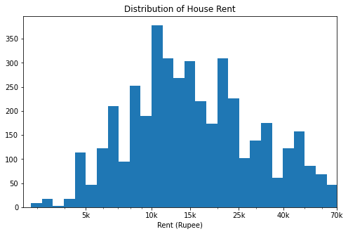

## Distribution of House Sizes

The house sizes are measured in square feet. size appears to be right skewed. Majority of the data are located at the low size range, with a steady decline after its peak 500 sqft.

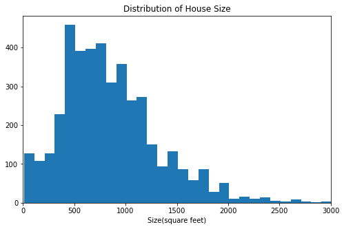

## House rent vs Size

The relationship between house rent to house size appears positive, the higher values of the size, the more the rent increases. The dark area of the graph indicates a higher volume of number of houses, the distribution appears to be below rent of 20000 and size 1500. Interestingly, some points have increased rent without increase in size.

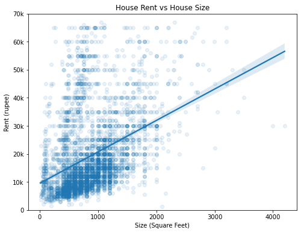

## House rent and House size by bhk and bathroom.

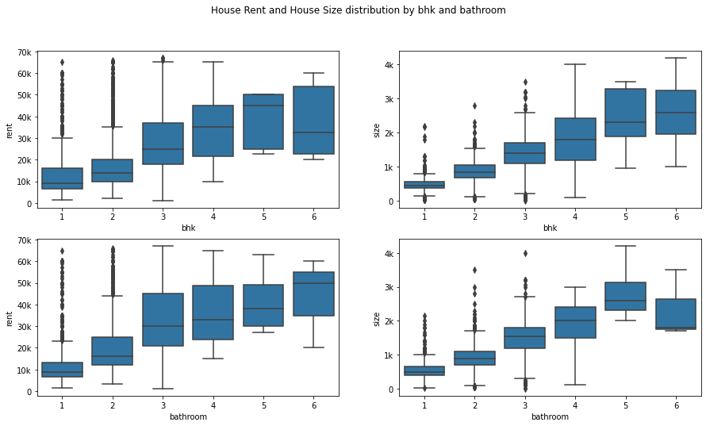

## House rent and House size by City.

The interactions city had with rent and size is interesting, cities like Kolkata, Bangalore, Delhi, Chennai and Hyderabad all had a linear increase in rent except for Mumbai which has a non-linear increase of rent. Houses size in Mumbai ranges around 100 - 1500 square feet and house rent ranges around 2000 - 65000 rupees. This explains the reason behind the non-linear increase of house rent noticed earlier in the **house rent vs house size** graph.

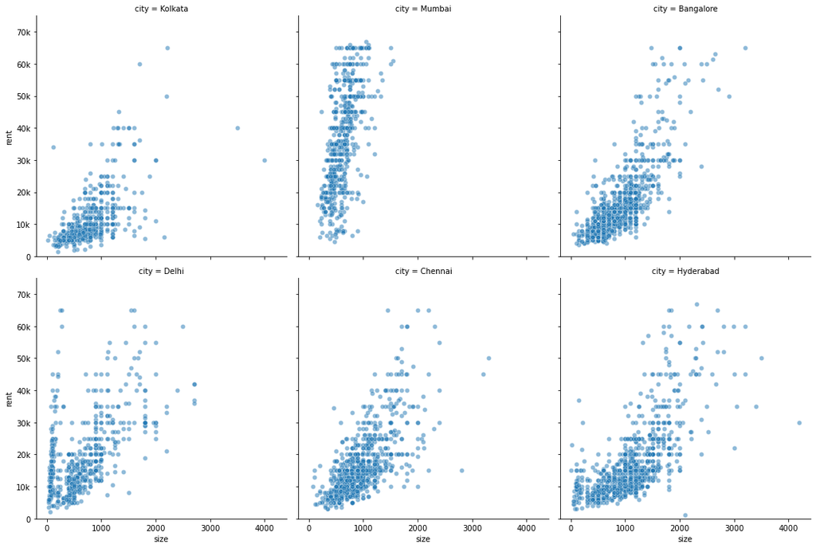

## House rent by City for Selected Norminal variables (area Typye & Point of Contact)

We used both area type and point of contact. This is most evident for the City measure. The point plot of rent with city against area type and point of contact shows an interesting feature. Here we can clearly identify the features of both norminal variables that corresponds with rent increase inline with various cities.  
Carpet area type has its highest rent around 40,000 rupees and this occurs for houses only in Mumbai. Also, contact agent turns out to be the highest in house rent, with its highest around 40,000 occurred in Mumbai. Most houses in Mumbai are built in carpet area and point of contact are by agents. House rent in Mumbai increases regardless of the sizes of the house. These features are the secondary causes of house rent increase, which a high number of them occurred in Mumbai.

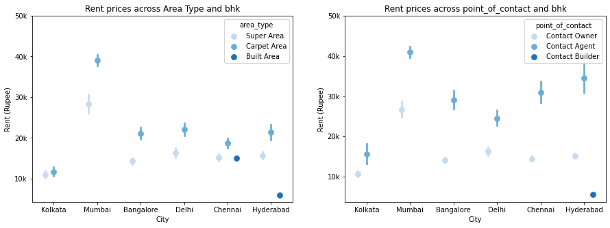